# AP-4209 ESIEE-Paris: 2023 -2024

Projet 2 : Analyse factorielle discriminante

Adrien LINDEBERG – Théo LINDQVIST  
ESIEE Paris - DSIA

Introduction: Ce projet est basé sur l’AFD. Nous développerons un projet sur l’analyse factorielle discriminante en utilisant l’ensemble de données sur les sentiments ([Sentiment Dataset](https://www.kaggle.com/datasets/jp797498e/twitter-entity-sentiment-analysis)). Notre dataset possède quatre colonnes. - Tweet ID: il s’agit de l’id du tweet. - entity: cette colonne nous permettra de savoir sur quelle entité est le tweet . - sentiment :il s’agit du semtiment correspondant au tweet. - Tweet content : il s’agit du contenu du tweet. L’objectif sera de prédire le sentiment correspondant au tweet à partir des autres colonnes. Pour cela, nous allons employer une série de pré-traitement pour rendre notre modèle plus fiable et robuste. Puis, nous allons faire subir à notre dataset une réduction de dimensionalité et enfin évaluer notre modèle.

Objectif principal : Utiliser l’analyse factorielle discriminante (AFD) pour réduire les dimensions des données des tweets et visualiser le regroupement des sentiments.

### 1. Chargement et pré-traitement des données :

Nous allons explorer notre dataset afin de mieux comprendre la manière dont il est construit et mieux préparer le prétraitement des données afin de permettre une meilleure analyse factorielle discriminante.

On n’oublie pas d’abord d’effacer toutes les variables en mémoire:

```r
rm(list = ls())

gc()
```

```
##          used (Mb) gc trigger (Mb) max used (Mb)
## Ncells 524267 28.0    1167714 62.4   660382 35.3
## Vcells 960479  7.4    8388608 64.0  1770407 13.6
```

##### 1.1 Chargement du jeu de données dans R :

On charge les packages nécessaires:

```r
library(ggplot2)
library(lattice)
library(kableExtra)
library(caret)
library(RColorBrewer)
library(wordcloud)
library(tidyverse)
library(stringr)
library(text)
library(tidytext)
library(textstem)
library(tm)
library(reshape2)
require(sentimentr)
library(syuzhet)
library(lubridate)
library(scales)
library(MASS)
```

Dans un premier temps, on charge nos datasets. Pour l’instant, on en a deux. Le premier correspond au dataset d’entrainement tandis que le deuxième correspond au dataset de test. Cependant, on va les fusionner pour que les prétraitements effectuer sur nos données soient bien fait sur l’ensemble de cell-ci nous permettant d’éviter de futures problèmes. On ajoutera aussi des noms au colonnes des datasets.

```r
#chargement des données
df_train <- read.csv("twitter_training.csv")
df_test <- read.csv("twitter_validation.csv")
#ajout du nom des colonnes
colnames(df_train) <- c("tweet_ID", "entity", "sentiment", "tweet_content")
colnames(df_test) <- c("tweet_ID", "entity", "sentiment", "tweet_content")

#on modifie l'ordre des colones pour que la colonne sentiment soit la dernière
#On supprime aussi la colonne tweet id car elle est unique pour chaque tweet et n'est dpad intéressant pour notre future modèle
df_train <- df_train[, c("tweet_content", "entity", "sentiment")]
df_test <- df_test[, c("tweet_content", "entity", "sentiment")]

#on fusionne les deux datasets pour extraire les caractéristiques des données textuelles sur toutes les données
df <- rbind(df_train, df_test)
```

```r
df %>%
  head() %>%
  kbl() %>%
  kable_styling(bootstrap_options = "striped", full_width = FALSE,
                position = "center")
```

| tweet_content | entity | sentiment |
| --- | --- | --- |
| I am coming to the borders and I will kill you all, | Borderlands | Positive |
| im getting on borderlands and i will kill you all, | Borderlands | Positive |
| im coming on borderlands and i will murder you all, | Borderlands | Positive |
| im getting on borderlands 2 and i will murder you me all, | Borderlands | Positive |
| im getting into borderlands and i can murder you all, | Borderlands | Positive |
| So I spent a few hours making something for fun. . . If you don’t know I am a HUGE @Borderlands fan and Maya is one of my favorite characters. So I decided to make myself a wallpaper for my PC. . Here… | Borderlands | Positive |

Comme dit dans l’introduction, notre dataset possède bien trois colonnes (entity, content, sentiment) avec différentes informations sur des tweet.

Maintenant, nous allons analyser les caractéristiques de notre dataset.

Pour commencer, on veut connaître ses dimensions:

```r
cat("Dimensions de df : ", dim(df), "\n")
```

```
## Dimensions de df :  75680 3
```

df possède plus de 75000 lignes et trois colonnes.

Notre dataset est très conséquent et si on on veut éviter tout overflow et des temps de run trop conséquent, on doit réduire le nombre de lignes de notre dataset. Pour cela, on utilise sample qui va récupérer aléatoirement 5000 index. On fixe cette partie aléatoire pour observer toujours les mêmes résultats ce qui est plus simple pour comparer nos différents tests.

```r
set.seed(42)
df <- df[sample(nrow(df), 5000, replace = FALSE), , drop = FALSE]
```

Arès le test de différentes tailles de dataset, on choisit que notre dataset fera 5000 lignes. On a choisi ce nombre car au dessus les caractéristiques de notre modèle ne s’améliore plus et le temps de run et l’overflow deviennent trop conséquent.

On vérifie qu’on ait bien les bonnes dimensions:

```r
cat("Nouvelles dimensions de df : ", dim(df), "\n")
```

```
## Nouvelles dimensions de df :  5000 3
```

On a bien un dataset df de 5000 lignes et trois colonnes.

On obtient une vue synthétique de df avec la fonction str():

```r
str(df)
```

```
## 'data.frame':    5000 obs. of  3 variables:
##  $ tweet_content: chr  "Looks to me like he failed to check out the way of moving vehicle that clearly had the right of way. Guess by s"| __truncated__ "This was better." "10 New in miniZ v1. 5t 8 Nvidia CUDA Miner Engine with Better Performance and Future Stability CRYPTO I CRYPTO "| __truncated…
##  $ entity       : chr  "GrandTheftAuto(GTA)" "CallOfDuty" "Nvidia" "Verizon" ...
##  $ sentiment    : chr  "Irrelevant" "Negative" "Neutral" "Negative" ...
```

Nous avons trois colones (entity, sentiment et tweet_content) qui sont de type chr.

On veut aussi savoir si il ya des valeurs manquantes et des valeurs vides dans notre dataset:

```r
cat("Nombre de valeurs manquantes de df : ", sum(is.na(df)), "\n")
```

```
## Nombre de valeurs manquantes de df :  0
```

```r
cat("Nombre de valeurs vides de df : ",
    sum(apply(df, 1, function(row) all(row == ""))), "\n")
```

```
## Nombre de valeurs vides de df :  0
```

Il n’y a aucune valeur manquante et valeur vide dans notre dataset.

On veut connaître tous les sentiments possibles:

```r
cat("Valeurs de la colonne Emotion : ", unique(df$sentiment), "\n")
```

```
## Valeurs de la colonne Emotion :  Irrelevant Negative Neutral Positive
```

Nous aurons donc 4 classes à prédire: “Positive” “Neutral” “Negative” “Irrelevant”.

On veux aussi connaitre toutes les entités présentes dans nos datasets

```r
cat("Valeurs de la colonne Emotion : ", unique(df$entity), "\n")
```

```
## Valeurs de la colonne Emotion :  GrandTheftAuto(GTA) CallOfDuty Nvidia Verizon HomeDepot PlayStation5(PS5) Overwatch Fortnite Facebook NBA2K ApexLegends Xbox(Xseries) MaddenNFL TomClancysRainbowSix Google Borderlands Microsoft TomClancysGhostRecon WorldOfCraft johnson&johnson CS-GO AssassinsCreed…
```

Il y a un grand nombre d’entités dans notre dataset (32 entitée).

Maintenant, on veut savoir si les sentiments sont uniformément réparti dans notre dataset. Pour cela, nous allons utiliser un barplot qui va compte le nombre d’occurences pour chaque sentiment.

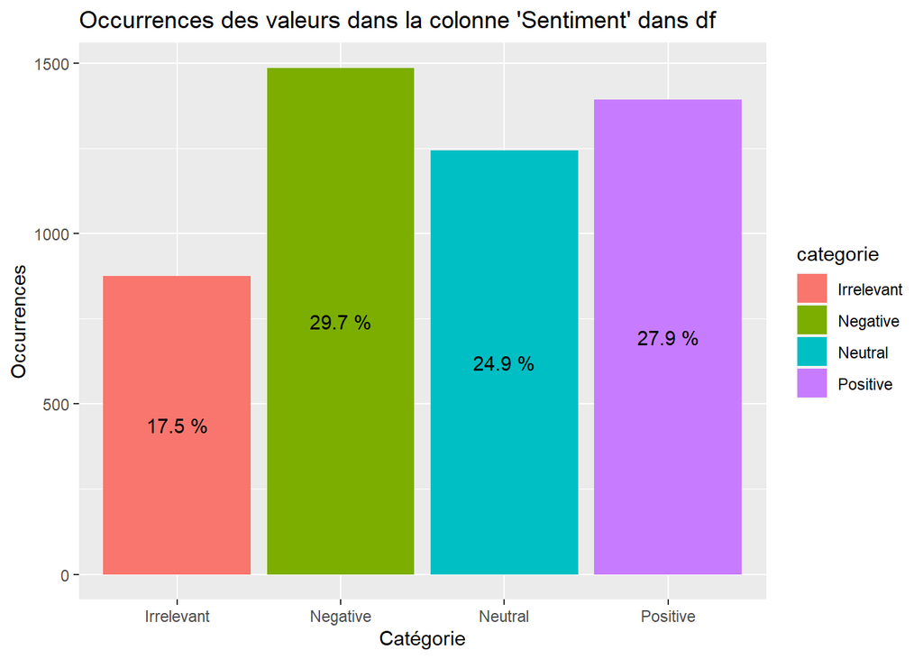

```r
occurrences <- table(df$sentiment)
occurrences_df <- as.data.frame(occurrences)
names(occurrences_df) <- c("categorie", "occurrences")

occurrences_df %>%
  ggplot(aes(x = categorie, y = occurrences, fill = categorie)) +
  geom_bar(stat = "identity") +
  geom_text(aes(label = paste(round(occurrences / nrow(df), 3) * 100, "%")),
            position = position_stack(vjust = 0.5)) +
  labs(title = "Occurrences des valeurs dans la colonne 'Sentiment' dans df",
       x = "Catégorie",
       y = "Occurrences")
```

On remarque que les quatre classes de sentiment ne sont pas uniformément répartis, il y a plus de sentiment négative avec 30% des valeurs puis positive et neutre avec 27 et 25% et pour finir seulement 17.5% de sentiment non défini. Il y a donc beaucoup moins de sentiment non défini ce qui pourrait poser problème lorsq’on devrai prédire ce sentiment.

On veut savoir maintenant quelles mots reviennent le plus dans la colonne tweet_content. Pouur cela on va transformer notre colonne Comment en corpus puis calculer la fréquence de chaque terme et afficher les mots qui reviennent le plus grâca à wordcloud:

```r
corpus <- Corpus(VectorSource(df$tweet_content))
corpus <- tm_map(corpus, content_transformer(tolower))
corpus <- tm_map(corpus, removePunctuation)
corpus <- tm_map(corpus, removeNumbers)
corpus <- tm_map(corpus, removeWords, stopwords("english"))
```

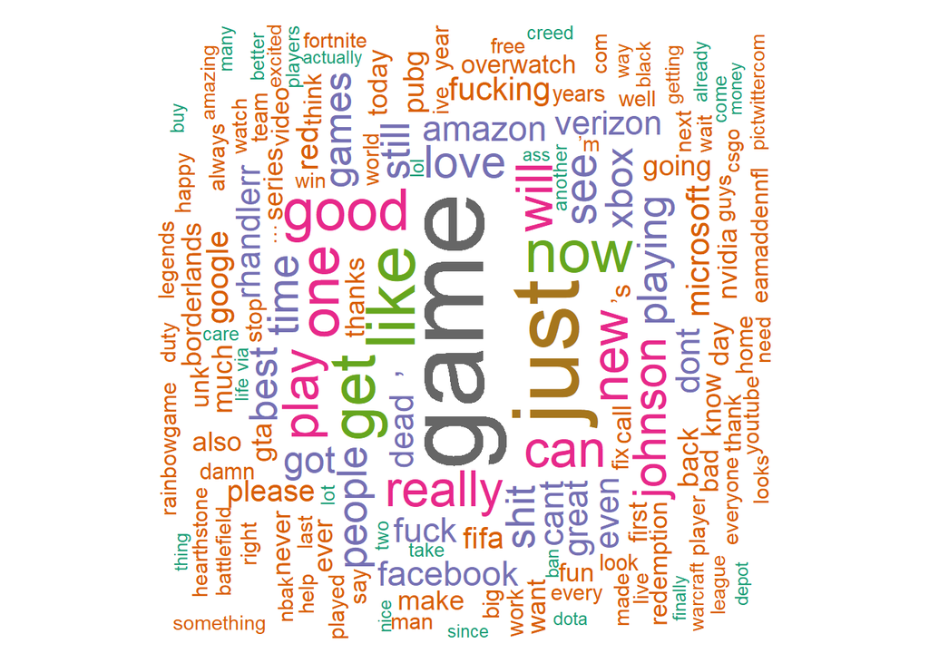

```r
tdm <- as.matrix(TermDocumentMatrix(corpus))

w <- sort(rowSums(tdm), decreasing = TRUE)
set.seed(222)
wordcloud(words = names(w),
          freq = w,
          max.words = 150,
          random.order = FALSE,
          min.freq = 5,
          colors = brewer.pal(8, "Dark2"),
          scale = c(5, 0.3),
          rot.per = 0.7)
```

Avant tout prétraitement, les mots qui reviennent le plus dans le dataset d’entrtainement sont game et just.

##### 1.2 Nettoyage des données textuelles des tweets :

Nous commençons dans cette partie le prétraitement de nos données.

Tout d’abord, nous allons nettoyer le contenu de nos tweets en supprimant la ponctuation, les caractères spéciaux, les urls, les emojis et les mots vides. Pour cela, on créer une fonction qui va les supprimer un par un.

```r
clean_text <- function(text) {
  #supprime les balises HTML
  text <- str_replace_all(text, "<.*?>", "")

  #met en minuscules
  text <- tolower(text)

  #supprime les URLs
  text <- str_replace_all(text, "http\\S+", "")
  text <- str_replace_all(text, "https\\S+", "")

  #supprime les caractères non-alphanumériques et la ponctuation
  text <- str_replace_all(text, "[^a-zA-Z\\s]", "")

  #supprime les emojis
  text <- str_replace_all(text, "[\\x{10000}-\\x{1FFFF}]", "")

  #supprime les mots vides
  stopwords <- stopwords("en")
  stopwords_pattern <- paste0("\\b", paste(stopwords,
                                           collapse = "\\b|\\b"), "\\b")
  text <- str_replace_all(text, stopwords_pattern, "")

  #supprimer les mots de moins de deux lettres
  text <- str_split(text, "\\s+")[[1]]
  text <- text[str_length(text) > 2]

  #reforme les commentaire
  preprocessed_text <- paste(text, collapse = " ")

  return(preprocessed_text)
}
```

On applique notre fonction à notre dataset grâce à sapply qui va appliquer la fonction ligne par ligne:

```r
df <- df %>%
  mutate(tweet_content = sapply(tweet_content, clean_text))
```

On peut voir que les modifications ont bien eu lieu.

```r
df %>%
  head() %>%
  kbl() %>%
  kable_styling(bootstrap_options = "striped", full_width = FALSE,
                position = "center")
```

|  | tweet_content | entity | sentiment |
| --- | --- | --- | --- |
| 61413 | looks like failed check way moving vehicle clearly right way guess stupidity | GrandTheftAuto(GTA) | Irrelevant |
| 54425 | better | CallOfDuty | Negative |
| 74362 | new miniz nvidia cuda miner engine better performance future stability crypto crypto news cryptocryptonews com com new miniz | Nvidia | Neutral |
| 46208 | anyone uses verizon fios internet see speed drop last two days | Verizon | Negative |
| 47128 | congrats retirement maureen made impact many people past years home depot thank wish best rhandlerr rhandlerr rhandlerr rhandlerr rhandlerr rhandlerr rhandlerr rhandlerr pictwittercomspgbrsky | HomeDepot | Positive |
| 16740 | miles getting game know bout hours late shit lost shit work coworkers decided peep rest home rachet clank always sick shit look eveb crazier | PlayStation5(PS5) | Negative |

On vérifie que le traitement a bien été appliqués sur lignes. Il n’y a bien plus de urls, caractères spéciaux, emojis, mots vides.

On regarde de nouveux les termes les plus fréquents de notre dataset avec wordcloud:

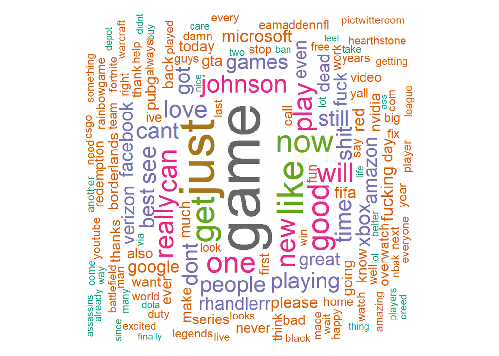

```r
corpus <- Corpus(VectorSource(df$tweet_content))
corpus <- tm_map(corpus, content_transformer(tolower))
corpus <- tm_map(corpus, removePunctuation)
corpus <- tm_map(corpus, removeNumbers)
corpus <- tm_map(corpus, removeWords, stopwords("english"))

# Créer le nuage de mots
tdm <- as.matrix(TermDocumentMatrix(corpus))

w <- sort(rowSums(tdm), decreasing = TRUE)
set.seed(222)
wordcloud(words = names(w),
          freq = w,
          max.words = 150,
          random.order = FALSE,
          min.freq = 5,
          colors = brewer.pal(8, "Dark2"),
          scale = c(5, 0.3),
          rot.per = 0.7)
```

Les termes les plus fréquents n’ont pas changé mais on remarque que certains termes ont disparus du nuage de mots.

##### 1.3 Convertir les étiquettes de sentiment dans un format adapté à DFA et lemmatization :

On doit maintenant convertir les étiquettes de sentiment dans un format numérique adapté à une DFA. On transforme donc la colonne en facteur.

```r
df$sentiment <- factor(df$sentiment, levels = unique(df$sentiment))

df %>%
  head() %>%
  kbl() %>%
  kable_styling(bootstrap_options = "striped", full_width = FALSE,
                position = "center")
```

|  | tweet_content | entity | sentiment |
| --- | --- | --- | --- |
| 61413 | looks like failed check way moving vehicle clearly right way guess stupidity | GrandTheftAuto(GTA) | Irrelevant |
| 54425 | better | CallOfDuty | Negative |
| 74362 | new miniz nvidia cuda miner engine better performance future stability crypto crypto news cryptocryptonews com com new miniz | Nvidia | Neutral |
| 46208 | anyone uses verizon fios internet see speed drop last two days | Verizon | Negative |
| 47128 | congrats retirement maureen made impact many people past years home depot thank wish best rhandlerr rhandlerr rhandlerr rhandlerr rhandlerr rhandlerr rhandlerr rhandlerr pictwittercomspgbrsky | HomeDepot | Positive |
| 16740 | miles getting game know bout hours late shit lost shit work coworkers decided peep rest home rachet clank always sick shit look eveb crazier | PlayStation5(PS5) | Negative |

Pour encoder la colonne sentiment, on utilise la fonction as.factor().

On fait la même chose avec la colonne entity mais cette fois on transforme aussi les valeurs en valeurs numériques car notre modèle de DFA prend que que des valeurs numérique pour les prédicteurs:

```r
df$entity <- as.numeric(factor(df$entity, levels = unique(df$entity))) - 1

df %>%
  head() %>%
  kbl() %>%
  kable_styling(bootstrap_options = "striped", full_width = FALSE,
                position = "center")
```

|  | tweet_content | entity | sentiment |
| --- | --- | --- | --- |
| 61413 | looks like failed check way moving vehicle clearly right way guess stupidity | 0 | Irrelevant |
| 54425 | better | 1 | Negative |
| 74362 | new miniz nvidia cuda miner engine better performance future stability crypto crypto news cryptocryptonews com com new miniz | 2 | Neutral |
| 46208 | anyone uses verizon fios internet see speed drop last two days | 3 | Negative |
| 47128 | congrats retirement maureen made impact many people past years home depot thank wish best rhandlerr rhandlerr rhandlerr rhandlerr rhandlerr rhandlerr rhandlerr rhandlerr pictwittercomspgbrsky | 4 | Positive |
| 16740 | miles getting game know bout hours late shit lost shit work coworkers decided peep rest home rachet clank always sick shit look eveb crazier | 5 | Negative |

On va maintenant appliquer une “tokenization” ainsi qu’une “lemmatization” et un “stemming” à notre dataset. Déjà, c’est quoi une tokenization ou une lemmatization?

Tokenization: c’est le processus de division d’un texte en unités plus petites appelées “tokens”. Un token peut être un mot, une phrase, ou même un caractère.

Stemming: c’est le processus de réduction des mots à leur racine ou base, en éliminant les suffixes.

Lemmatization: c’est une technique plus avancée que le stemming. Elle consiste à ramener les mots à leur forme canonique ou lemmatique, Contrairement au stemming, la lemmatisation produit des lemmes qui sont des mots valides dans la langue.

Pour cela, on code les deux fonctions suivantes:

```r
#applique la tokenization, la lemmatization et le stemming sur sentence
tokenize <- function(sentence) {
  words <- unlist(strsplit(sentence, " "))
  stemming <- SnowballC::wordStem(words, language = "en")
  lemme <- lemmatize_words(stemming)
  return(lemme)
}

#modifie lst pour qu'elle soit de la longueur = longueur_max
fill_with_empty <- function(lst) {
  if (length(lst) < longueur_max) {
    return(c(lst, rep("", longueur_max - length(lst))))
  } else {
    return(lst)
  }
}
```

tokenize: prend en paramètre une phrase et revoit une liste avec un mot à chaque index où chaque mot a subi une lemmatization et un stemming permettant de revenir à la racine du mot.

fill_with_empty: prend en paramètre une liste et si elle plus petite que longueur_max alors cette fonction ajoute “” jusqu’à qu’elle soit de la taille longueur_max

On applique nos fonctions sur le contenu de chaque tweets:

```r
#récupération de la colonne tweet_content
content_train <- df$tweet_content

#application de la tokenization, stemming et lemmatization
X_token <- lapply(content_train, tokenize)
longueur_max <- max(sapply(X_token, length))
X_filled <- lapply(X_token, fill_with_empty)
X_final <- as.data.frame(do.call(rbind, X_filled))

remove_numbers <- function(x) gsub("\\d", "", x)

#on reconcatène les mots de nos commentaires
X_final <- mutate_all(X_final, remove_numbers)
sentence <- data.frame(tweet_content = apply(X_final,
                                             1, function(row) paste(row[row != ""], collapse = " ")))

#on remplace les commentaires par les commentaires ayant subi les modifications
df$tweet_content <- sentence$tweet_content

#on vérifie qu'il y a toujours pas de valeurs manquantes ou vides
sum(is.na(sentence))
```

```
## [1] 0
```

```r
sum(apply(sentence, 1, function(row) all(row == "")))
```

```
## [1] 181
```

```r
#on supprime les valeurs vides de tweet_content
df <- df %>% filter(tweet_content != "")
sum(apply(df, 1, function(row) all(row == "")))
```

```
## [1] 0
```

```r
df %>%
  head(10) %>%
  kbl() %>%
  kable_styling(bootstrap_options = "striped", full_width = FALSE,
                position = "center")
```

| tweet_content | entity | sentiment |
| --- | --- | --- |
| look like fail check way move vehicl clear right way guess stupid | 0 | Irrelevant |
| good | 1 | Negative |
| new miniz nvidia cuda miner engin good perform futur stabil crypto crypto news cryptocryptonew com com new miniz | 2 | Neutral |
| anyon use verizon fio internet see speed drop last two day | 3 | Negative |
| congrat retir maureen make impact mani peopl past year home depot thank wish good rhandlerr rhandlerr rhandlerr rhandlerr rhandlerr rhandlerr rhandlerr rhandlerr pictwittercomspgbrski | 4 | Positive |
| mile get game know bout hour late shit lose shit work cowork decid peep rest home rachet clank alway sick shit look eveb crazy | 5 | Negative |
| year late queen pop bless origin icon singl music britney bitch gimm mord first lead singl bibl pop fun fact song featur gta radio | 0 | Irrelevant |
| daili top popular stock nvidia nvda popular splunk splk popular expedia exp popular broadcom avgo popular taketwo ttwo popular | 2 | Positive |
| playoverwatch year reinhardt still cant cancel free realli | 6 | Negative |
| didnt gta kick inact | 0 | Neutral |

Le contenu des tweets ont subi une lemmatization et un stemming pour revenir aux racines des mots et pour que nos données soient adaptés à DFA. On remarque après l’application de nos fonction de nouvelles valeurs vides, on les supprime de noouveau.

### 2. feature engineering :

On va tester différentes techniques d’extraction des caractéristiques des données textuelles et gardée les meilleures.

En premier, nous allons ajouter un score qui correspont au sentiment associé au tweets. Pour cela, on utilisera la fonction sentiment de la librairie sentimentr.

```r
sentiment_feature <- as.data.frame(sentiment(df$tweet_content))
#on doit modifier le nom de la colonne sentiment car on a déjà une colonne avec ce nom dans df
colnames(sentiment_feature)[colnames(sentiment_feature) == "sentiment"] <- "sentiment_analysis"
df <- cbind(df, sentiment_feature[, c("word_count", "sentiment_analysis")])

df <- df[, c("tweet_content", "entity", "word_count",
             "sentiment_analysis", "sentiment")]
df %>%
  head() %>%
  kbl() %>%
  kable_styling(bootstrap_options = "striped", full_width = FALSE,
                position = "center")
```

| tweet_content | entity | word_count | sentiment_analysis | sentiment |
| --- | --- | --- | --- | --- |
| look like fail check way move vehicl clear right way guess stupid | 0 | 12 | 0.0144338 | Irrelevant |
| good | 1 | 1 | 0.7500000 | Negative |
| new miniz nvidia cuda miner engin good perform futur stabil crypto crypto news cryptocryptonew com com new miniz | 2 | 18 | 0.5539003 | Neutral |
| anyon use verizon fio internet see speed drop last two day | 3 | 11 | 0.0000000 | Negative |
| congrat retir maureen make impact mani peopl past year home depot thank wish good rhandlerr rhandlerr rhandlerr rhandlerr rhandlerr rhandlerr rhandlerr rhandlerr pictwittercomspgbrski | 4 | 23 | 0.4274545 | Positive |
| mile get game know bout hour late shit lose shit work cowork decid peep rest home rachet clank alway sick shit look eveb crazy | 5 | 24 | -0.9389711 | Negative |

On obtient ici de nouvelles colonnes, le nombre de termes par tweets et un score suite à l’analyse du sentiment du tweet.

Nous allons maintenant procéder à la vectorisation du texte en utilisant la méthode de la fréquence des termes et de la fréquence inverse du document. Pour cela, on utilise la librairie tm et sa fonction DocumentTermMatrix.

```r
#créer un corpus à partir de chaque ligne du dataframe
corpus <- iconv(df$tweet_content)
corpus <- Corpus(VectorSource(corpus))
corpus <- tm_map(corpus, tolower)
corpus <- tm_map(corpus, removePunctuation)
corpus <- tm_map(corpus, removeNumbers)
corpus <- tm_map(corpus, stripWhitespace)
cleanset <- tm_map(corpus, removeWords, stopwords("english"))
removeURL <- function(x) gsub("http[[:alnum:]]*", "", x)

cleanset <- tm_map(cleanset, content_transformer(removeURL))
cleanset <- tm_map(cleanset, stemDocument)
# représentation matricielle TF-IDF
dtm <- DocumentTermMatrix(corpus)
tfidf <- weightTfIdf(dtm)
tfidf <- as.matrix(tfidf)
tfidf_df <- as.data.frame(tfidf)

df <- cbind(df, tfidf_df)

df <- df[, -which(names(df) == "tweet_content"), drop = FALSE]

df[, 1:20] %>%
  head() %>%
  kbl() %>%
  kable_styling(bootstrap_options = "striped", full_width = FALSE,
                position = "center")
```

| entity | word_count | sentiment_analysis | sentiment | check | clear | fail | guess | like | look | move | right | stupid | vehicl | way | good | com | crypto | cryptocryptonew | cuda |
| --- | --- | --- | --- | --- | --- | --- | --- | --- | --- | --- | --- | --- | --- | --- | --- | --- | --- | --- | --- |
| 0 | 12 | 0.0144338 | Irrelevant | 0.5516507 | 0.7022636 | 0.6789213 | 0.637463 | 0.3283248 | 0.3868384 | 0.6278399 | 0.4927158 | 0.579093 | 0.7855969 | 1.024509 | 0.0000000 | 0.0000000 | 0.000000 | 0.0000000 | 0.0000000 |
| 1 | 1 | 0.7500000 | Negative | 0.0000000 | 0.0000000 | 0.0000000 | 0.000000 | 0.0000000 | 0.0000000 | 0.0000000 | 0.0000000 | 0.000000 | 0.0000000 | 0.000000 | 3.2177098 | 0.0000000 | 0.000000 | 0.0000000 | 0.0000000 |
| 2 | 18 | 0.5539003 | Neutral | 0.0000000 | 0.0000000 | 0.0000000 | 0.000000 | 0.0000000 | 0.0000000 | 0.0000000 | 0.0000000 | 0.000000 | 0.0000000 | 0.000000 | 0.1787617 | 0.6783595 | 1.183284 | 0.6796954 | 0.5685843 |
| 3 | 11 | 0.0000000 | Negative | 0.0000000 | 0.0000000 | 0.0000000 | 0.000000 | 0.0000000 | 0.0000000 | 0.0000000 | 0.0000000 | 0.000000 | 0.0000000 | 0.000000 | 0.0000000 | 0.0000000 | 0.000000 | 0.0000000 | 0.0000000 |
| 4 | 23 | 0.4274545 | Positive | 0.0000000 | 0.0000000 | 0.0000000 | 0.000000 | 0.0000000 | 0.0000000 | 0.0000000 | 0.0000000 | 0.000000 | 0.0000000 | 0.000000 | 0.1399004 | 0.0000000 | 0.000000 | 0.0000000 | 0.0000000 |
| 5 | 24 | -0.9389711 | Negative | 0.0000000 | 0.0000000 | 0.0000000 | 0.000000 | 0.0000000 | 0.1934192 | 0.0000000 | 0.0000000 | 0.000000 | 0.0000000 | 0.000000 | 0.0000000 | 0.0000000 | 0.000000 | 0.0000000 | 0.0000000 |

On a remplacé la colonne tweet_content par un nommbre importants de colonnes. On a maintenant une colonne pour chaque terme qui apparrait dans un tweets et si le terme apparait dans un tweet alors à cette ligne alors la colonne de ce terme prendre comme valeur la fréquence du terme sinon elle prend zéro comme valeur.

### 3. Analyse discriminante linéaire (LDA) :

Tout d’abord, c’est quoi une analyse discriminante linéaire (LDA)?

L’analyse discriminante linéaire (LDA) est une méthode statistique appartenant à la catégorie des techniques prédictives d’analyse discriminante. Son objectif est d’expliquer et de prédire l’inclusion d’un individu dans une classe préalablement définie en utilisant ses caractéristiques mesurées par le biais de variables prédictives.

Tout d’abors, nous devons séparer notre dataset en un dataset d’entrtainement et de test. Nous allons placer 80% de nos données dans le dataset d’entrainement grâce à la fonction createDataPartition qui nous retourne les indexs des lignes qui iront dans notre datasets d’entrainement. On doit aussi supprimer les colonnes contants car notre modèle nous retourne une erreur mais ces colonnes ne sont pas importantes car cela signifie que ce terme apparraissent rarement et ne sont pas importants pour le modèle.

```r
idx <- df$sentiment %>%
  createDataPartition(p = 0.8, list = FALSE)

train_data <- df[idx, ]
test_data <- df[-idx, ]

#identifier les colonnes constantes
constant_cols <- apply(train_data, 2, function(x) length(unique(x)) == 1)
#supprimer les colonnes constantes
train_data <- train_data[, !constant_cols]
test_data <- test_data[, !constant_cols]

# parameter <- train_data[-4] %>%
#   preProcess(method = c("center", "scale"))

# train_data[-4] <- parameter %>% predict(train_data[-4])
# test_data[-4] <- parameter %>% predict(test_data[-4])

X_train <- train_data[, -which(names(train_data) == "sentiment"), drop = FALSE]
y_train <- train_data$sentiment
X_test <- test_data[, -which(names(test_data) == "sentiment"), drop = FALSE]
y_test <- test_data$sentiment

cat("Dimensions de X_train : ", dim(X_train), "\n")
```

```
## Dimensions de X_train :  3856 7514
```

```r
cat("Dimensions de X_test : ", dim(X_test), "\n")
```

```
## Dimensions de X_test :  963 7514
```

```r
train_data %>%
  head() %>%
  kbl() %>%
  kable_styling(bootstrap_options = "striped", full_width = FALSE,
                position = "center")
```

|  | entity | word_count | sentiment_analysis | sentiment | check | clear | fail | guess | like | look | move | right | stupid | vehicl | way | good | com | crypto | cryptocryptonew | cuda | engin | futur | miner | miniz | new | news | nvidia | perform | stabil | … |
| --- | --- | --- | --- | --- | --- | --- | --- | --- | --- | --- | --- | --- | --- | --- | --- | --- | --- | --- | --- | --- | --- | --- | --- | --- | --- | --- | --- | --- | --- | --- |
| 3 | 2 | 18 | 0.5539003 | Neutral | 0 | 0 | 0 | 0 | 0 | 0.0000000 | 0 | 0 | 0 | 0 | 0 | 0.1787617 | 0.6783595 | 1.183284 | 0.6796954 | 0.5685843 | 0.5130288 | 0.5035885 | 0.6241399 | 1.24828 | 0.4984806 | 0.3614776 | 0.3051695 | 0.4019177 | 0.6241399 | … |
| 4 | 3 | 11 | 0.0000000 | Negative | 0 | 0 | 0 | 0 | 0 | 0.0000000 | 0 | 0 | 0 | 0 | 0 | 0.0000000 | 0.0000000 | 0.000000 | 0.0000000 | 0.0000000 | 0.0000000 | 0.0000000 | 0.0000000 | 0.00000 | 0.0000000 | 0.0000000 | 0.0000000 | 0.0000000 | 0.0000000 | … |
| 5 | 4 | 23 | 0.4274545 | Positive | 0 | 0 | 0 | 0 | 0 | 0.0000000 | 0 | 0 | 0 | 0 | 0 | 0.1399004 | 0.0000000 | 0.000000 | 0.0000000 | 0.0000000 | 0.0000000 | 0.0000000 | 0.0000000 | 0.00000 | 0.0000000 | 0.0000000 | 0.0000000 | 0.0000000 | 0.0000000 | … |
| 6 | 5 | 24 | -0.9389711 | Negative | 0 | 0 | 0 | 0 | 0 | 0.1934192 | 0 | 0 | 0 | 0 | 0 | 0.0000000 | 0.0000000 | 0.000000 | 0.0000000 | 0.0000000 | 0.0000000 | 0.0000000 | 0.0000000 | 0.00000 | 0.0000000 | 0.0000000 | 0.0000000 | 0.0000000 | 0.0000000 | … |
| 8 | 2 | 19 | 0.9176629 | Positive | 0 | 0 | 0 | 0 | 0 | 0.0000000 | 0 | 0 | 0 | 0 | 0 | 0.0000000 | 0.0000000 | 0.000000 | 0.0000000 | 0.0000000 | 0.0000000 | 0.0000000 | 0.0000000 | 0.00000 | 0.0000000 | 0.0000000 | 0.2891080 | 0.0000000 | 0.0000000 | … |
| 10 | 0 | 4 | 0.1250000 | Neutral | 0 | 0 | 0 | 0 | 0 | 0.0000000 | 0 | 0 | 0 | 0 | 0 | 0.0000000 | 0.0000000 | 0.000000 | 0.0000000 | 0.0000000 | 0.0000000 | 0.0000000 | 0.0000000 | 0.00000 | 0.0000000 | 0.0000000 | 0.0000000 | 0.0000000 | 0.0000000 | … |

Avant de faire notre analyse discriminante linéaire (LDA), nous voulons connaitre la structure de notre dataset :

```r
P <- ncol(X_train)
P
```

```
## [1] 7514
```

```r
N <- nrow(X_train)
N
```

```
## [1] 3856
```

```r
K <- length(unique(y_train))
K
```

```
## [1] 4
```

```r
G <- colMeans(X_train)
```

Nous avons N = 3856 qui correspond au nombre d’observations disponibles pour les calculs, P = 7514 qui est le nombre de variables explicatives et K = 4 qui est le nombre de classes que l’on devra prédire {Positive, Negative, Neutral, Irrelevant}.

Pour lancer l’analyse discriminante, nous utiliserons le modèle lda du package “MASS”. Ce modèle prend en paramètres une formule qui dit par rapport à quels colonnes on veut prédire nos classes. Nous nous voulons prédire la colonne sentiment par rapport à toutes les autres colonnes d’où l’utilisation de . qui dit à notre modèle d’utiliser toutes les colonnes de notre dataset. On met en commentaires les résumés de notre modèle car on a plis de 7000 colonnes ce qui le rend très long et illisible.

```r
mLda <- lda(sentiment ~ ., data = train_data)
# mLda
```

On affiche quelques caractéristique de notre modèle comme les constantes des fonctions canoniques ou les moyennes conditionnelles:

```r
# # liste des propriétés de l’objet
# attributes(mLda)
# #a distribution relative des classes
# mLda$prior
# # distribution absolue
# mLda$counts
# # moyennes des variables conditionnellement aux classes
# mLda$means
# # matrice des coefficients des fonctions discriminantes
# mLda$scaling
# # libéllés des classes
# mLda$lev
# Constantes des fonctions canoniques
const_ <- apply(mLda$scaling, 2, function(v) {- sum(v * G)})
const_
```

```
##       LD1       LD2       LD3
##  2.398803 -6.552344  8.584566
```

```r
# Moyennes conditionnelles
cond_xb <- sapply(1:ncol(mLda$scaling), function(j)
                  {sapply(mLda$lev,
                  function(niveau){sum(mLda$scaling[, j] * mLda$means[niveau, ]) + const_[j]})
                  })
colnames(cond_xb) <- paste("LD",1:ncol(mLda$scaling), sep = "")
rownames(cond_xb) <- mLda$lev
cond_xb
```

```
##                   LD1       LD2         LD3
## Irrelevant -18.708553  3.887275  0.01737014
## Negative     2.498689 -6.420654 -7.67144689
## Neutral      7.359107 12.106177 -0.06060713
## Positive     2.558458 -6.313511  8.24185958
```

```r
# # Coefficients des fonctions de classement déduits des fonctions canoniques
# coef_ <- sapply(mLda$lev, function(niveau)
#                 {rowSums(sapply(1:ncol(mLda$scaling),
#                                 function(j) {mLda$scaling[, j] * cond_xb[niveau, j]}))
#                 })
# coef_
# # Intercept des fonctions de classement
# intercept_ <- sapply(mLda$lev, function(niveau)
#                      {sum(mapply(prod, const_, cond_xb[niveau,])) - 0.5 * sum(cond_xb[niveau, ]^2) + log(mLda$prior[niveau])})
# names(intercept_) <- levels(df$sentiment)
# intercept_
```

### 4. Visualisation :

Nous allons utiliser l’échantillon test dans cette section pour inspecter les propriétés des sorties de predict() appliquée à un objet lda(). Tout d’abord, on va visualiser les résultats de l’AFD pour déterminer comment les tweets sont regroupés par sentiment dans l’espace réduit.

Nous utilisons la fonction predict() sur X_test:

```r
predictions <- predict(mLda, newdata = X_test)
attributes(predictions)
```

```
## $names
## [1] "class"     "posterior" "x"
```

On observe les premières coordonnées factorielles des individus en test:

```r
head(predictions$x, 5)
```

```
##           LD1       LD2        LD3
## 1  -30.294549 -4.210845  13.933759
## 2    2.906956 -4.216081   4.229959
## 7  -35.595041  1.078377  -4.903724
## 9  -21.672909 -7.870889 -27.963296
## 21  25.066290  6.932518 -26.032958
```

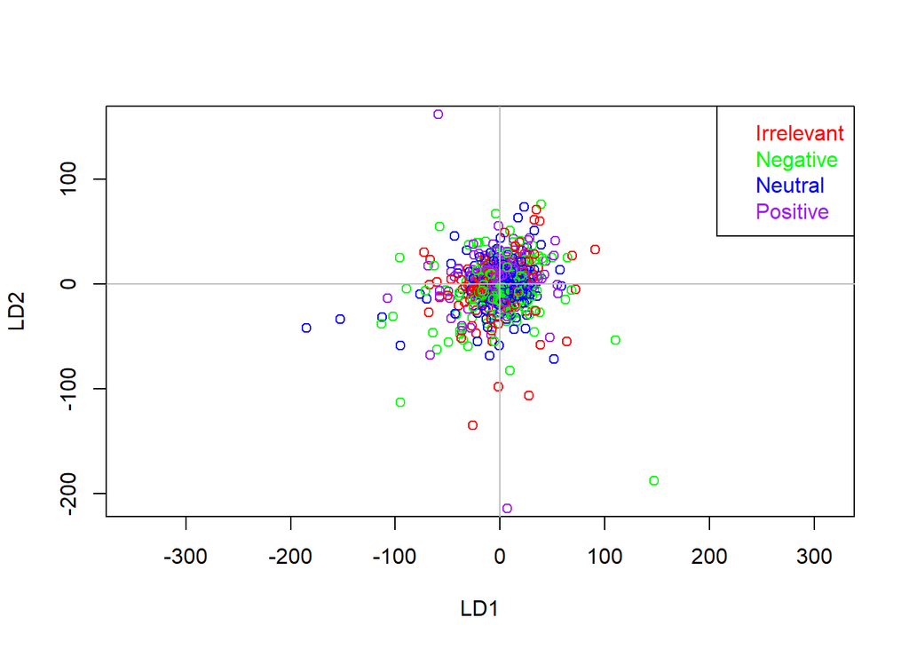

```r
eqscplot(predictions$x[, 1], predictions$x[, 3],
         col = c("red", "green", "blue", "purple")[y_test],
         xlab = "LD1", ylab = "LD2")
legend("topright", legend = levels(y_test),
       text.col = c("red", "green", "blue", "purple"))
abline(h = 0, col = "gray")
abline(v = 0, col = "gray")
```

### 5. Évaluation du modèle :

Pour finir, on va évaluer notre modèle, observer ces différentes caractéristiques afin de comprendre ces points forts et faibles.

Tout d’abord, on affiche les scores des premières prédictions:

```r
head(predictions$posterior)
```

```
##       Irrelevant      Negative       Neutral      Positive
## 1   1.000000e+00 5.409855e-251 2.470328e-323 1.899395e-157
## 2  5.067313e-116  4.534663e-28  1.867493e-62  1.000000e+00
## 7   1.000000e+00 1.376709e-260  0.000000e+00 4.034607e-297
## 9   1.000000e+00  2.679464e-15 2.195332e-237 2.977506e-211
## 21  0.000000e+00  8.572919e-03  9.914271e-01 1.665972e-183
## 27  1.000000e+00 5.324838e-142  3.252680e-50 8.860461e-157
```

Maintenant, on affiche la matrice de confusion et les métriques du modèle (recall, score F1, accuracy) pour mieux vizualiser la répartition des prédictions:

```r
caret::confusionMatrix(reference = y_test, data = predictions$class)
```

```
## Confusion Matrix and Statistics
##
##             Reference
## Prediction   Irrelevant Negative Neutral Positive
##   Irrelevant         70       55      49       54
##   Negative           27      109      44       47
##   Neutral            25       53      76       38
##   Positive           47       70      69      130
##
## Overall Statistics
##
##                Accuracy : 0.3998
##                  95% CI : (0.3687, 0.4315)
##     No Information Rate : 0.298
##     P-Value [Acc > NIR] : 1.120e-11
##
##                   Kappa : 0.1968
##
##  Mcnemar's Test P-Value : 1.515e-05
##
## Statistics by Class:
##
##                      Class: Irrelevant Class: Negative Class: Neutral
## Sensitivity                    0.41420          0.3798        0.31933
## Specificity                    0.80101          0.8254        0.84000
## Pos Pred Value                 0.30702          0.4802        0.39583
## Neg Pred Value                 0.86531          0.7582        0.78988
## Prevalence                     0.17549          0.2980        0.24714
## Detection Rate                 0.07269          0.1132        0.07892
## Detection Prevalence           0.23676          0.2357        0.19938
## Balanced Accuracy              0.60760          0.6026        0.57966
##                      Class: Positive
## Sensitivity                   0.4833
## Specificity                   0.7320
## Pos Pred Value                0.4114
## Neg Pred Value                0.7852
## Prevalence                    0.2793
## Detection Rate                0.1350
## Detection Prevalence          0.3281
## Balanced Accuracy             0.6076
```

En observant la matrice de confusion et les différentes métriques, on remarque que notre modèle présente quelques problèmes. Déjà, son accuracy de 40% est faible ce qui met en avant sa difficulté a prédire la bonne classe. On remarque que la sensitivité de chaque classe est un peu différentes. En effet, notre modèle prédit plus facilement la classe positive (sensitivity = 0.48) tandis que pour la classe neutral il a de grandes difficultés (sensitivity = 0.32). C’est résultat sont confirmé par notre matrice de confusion où l’on voit bien que notre modèle prédit plus souvent correctement lorsque qu’il doit trouvé positive que les autres classes. Le coefficient Kappa de 0.2 indique aussi un accord faible entre les prédictions du modèle et les observations réelles.

Ainsi, on comprend bien que notre modèle n’est pas fiable. Cela peut être dû à différentes raisons, une LDA défaillaite ou un prétraitement qui ne fait pas sortir les caractéristiques souhaités par exemple.

### 6. Conclusion :

Pour conclure, on sera parti d’un dataset très imposant de plus de 75000 lignes que l’on aura du réduire à 5000. Pour faire ressortir les caractéristiques des tweets, on aura utiliser une TF-IDF et une analyse de sentiment passant de 3 lignes a plus de 7500.

Ensuite, on a utilisé une analyse factorielle discriminante pour réduire les dimensions des données des tweets et visualiser le regroupement des sentiments. Pour cela, on a utilisé une lda de la librairie MASS nous permettant de réduire notre modèle à trois colonnes. Puis en testant notre modèle, nous avons remarqués que les résultats n’étaient pas fiable avec une accuracy de 40% et un taux de faux positifs et de faux négatifs très élevés.

Pour améliorer notre modèle, il serait nécessaire d’essayer d’autres features engineering permettant de faire ressortir d’autres caractéristiques plus intéressantes des tweets.